# Part I - (Prosper Loan Data Exploration)

## Introduction

The Prosper Loan dataset contains information about over 110,000 loan listings and 81 varaibles pointing to a number of factors relating to the loan. The dataset was provided by Udacity and was downloaded manually from the link provided in the classroom. Some popular variables include:

- `LoanStatus` - Indicating the status of the loan. Whether it's cancelled, completed, defaulted or even past due date.
- `ListingCategory` - The reason the borrower took the loan. Examples include Auto, Engagement rings, Wedding loans, and reasons as weird as Taxes.
- `Occupation` - This contains the occupation of the borrower.

Other interesting variables abound in the dataset, and for this project we would be exploring the different variables and how they relate to one another. We would also be plotting some visualizations using univariate, bivariate, and multivariate plots to explore many relationships in the data set. Some findings and key insights would also be derived for a slidedeck presentation.

## Preliminary Wrangling

Before we proceed to analysis and visualization, we first have to clean the dataset and make it tidy enough for use. We would also be dropping some columns that won't be necessary for our analysis. Let's proceed to viewing the dataset and assessing for quality and tidiness issues briefly, then doing some little cleaning.

```python
# import all packages and set plots to be embedded inline
import numpy as np
import pandas as pd
import matplotlib.pyplot as plt
import seaborn as sns

# magic command to display all charts in this notebook
%matplotlib inline
```

```python
# reading in the csv into a pandas dataframe and viewing it for assessment
loan = pd.read_csv('prosperLoanData.csv')
loan.head()
```

|  | ListingKey | ListingNumber | ListingCreationDate | CreditGrade | Term | LoanStatus | ClosedDate | BorrowerAPR | BorrowerRate | LenderYield | ... | LP_ServiceFees | LP_CollectionFees | LP_GrossPrincipalLoss | LP_NetPrincipalLoss | LP_NonPrincipalRecoverypayments | PercentFunded | Recommendations | InvestmentFromFriendsCount | InvestmentFromFriendsAmount | Investors |
| --- | --- | --- | --- | --- | --- | --- | --- | --- | --- | --- | --- | --- | --- | --- | --- | --- | --- | --- | --- | --- | --- |
| 0 | 1021339766868145413AB3B | 193129 | 2007-08-26 19:09:29.263000000 | C | 36 | Completed | 2009-08-14 00:00:00 | 0.16516 | 0.1580 | 0.1380 | ... | -133.18 | 0.0 | 0.0 | 0.0 | 0.0 | 1.0 | 0 | 0 | 0.0 | 258 |
| 1 | 10273602499503308B223C1 | 1209647 | 2014-02-27 08:28:07.900000000 | NaN | 36 | Current | NaN | 0.12016 | 0.0920 | 0.0820 | ... | 0.00 | 0.0 | 0.0 | 0.0 | 0.0 | 1.0 | 0 | 0 | 0.0 | 1 |
| 2 | 0EE9337825851032864889A | 81716 | 2007-01-05 15:00:47.090000000 | HR | 36 | Completed | 2009-12-17 00:00:00 | 0.28269 | 0.2750 | 0.2400 | ... | -24.20 | 0.0 | 0.0 | 0.0 | 0.0 | 1.0 | 0 | 0 | 0.0 | 41 |
| 3 | 0EF5356002482715299901A | 658116 | 2012-10-22 11:02:35.010000000 | NaN | 36 | Current | NaN | 0.12528 | 0.0974 | 0.0874 | ... | -108.01 | 0.0 | 0.0 | 0.0 | 0.0 | 1.0 | 0 | 0 | 0.0 | 158 |
| 4 | 0F023589499656230C5E3E2 | 909464 | 2013-09-14 18:38:39.097000000 | NaN | 36 | Current | NaN | 0.24614 | 0.2085 | 0.1985 | ... | -60.27 | 0.0 | 0.0 | 0.0 | 0.0 | 1.0 | 0 | 0 | 0.0 | 20 |

5 rows × 81 columns

```python
loan.describe()
```

|  | ListingNumber | Term | BorrowerAPR | BorrowerRate | LenderYield | EstimatedEffectiveYield | EstimatedLoss | EstimatedReturn | ProsperRating (numeric) | ProsperScore | ... | LP_ServiceFees | LP_CollectionFees | LP_GrossPrincipalLoss | LP_NetPrincipalLoss | LP_NonPrincipalRecoverypayments | PercentFunded | Recommendations | InvestmentFromFriendsCount | InvestmentFromFriendsAmount | Investors |
| --- | --- | --- | --- | --- | --- | --- | --- | --- | --- | --- | --- | --- | --- | --- | --- | --- | --- | --- | --- | --- | --- |
| count | 1.139370e+05 | 113937.000000 | 113912.000000 | 113937.000000 | 113937.000000 | 84853.000000 | 84853.000000 | 84853.000000 | 84853.000000 | 84853.000000 | ... | 113937.000000 | 113937.000000 | 113937.000000 | 113937.000000 | 113937.000000 | 113937.000000 | 113937.000000 | 113937.000000 | 113937.000000 | 113937.000000 |
| mean | 6.278857e+05 | 40.830248 | 0.218828 | 0.192764 | 0.182701 | 0.168661 | 0.080306 | 0.096068 | 4.072243 | 5.950067 | ... | -54.725641 | -14.242698 | 700.446342 | 681.420499 | 25.142686 | 0.998584 | 0.048027 | 0.023460 | 16.550751 | 80.475228 |
| std | 3.280762e+05 | 10.436212 | 0.080364 | 0.074818 | 0.074516 | 0.068467 | 0.046764 | 0.030403 | 1.673227 | 2.376501 | ... | 60.675425 | 109.232758 | 2388.513831 | 2357.167068 | 275.657937 | 0.017919 | 0.332353 | 0.232412 | 294.545422 | 103.239020 |
| min | 4.000000e+00 | 12.000000 | 0.006530 | 0.000000 | -0.010000 | -0.182700 | 0.004900 | -0.182700 | 1.000000 | 1.000000 | ... | -664.870000 | -9274.750000 | -94.200000 | -954.550000 | 0.000000 | 0.700000 | 0.000000 | 0.000000 | 0.000000 | 1.000000 |
| 25% | 4.009190e+05 | 36.000000 | 0.156290 | 0.134000 | 0.124200 | 0.115670 | 0.042400 | 0.074080 | 3.000000 | 4.000000 | ... | -73.180000 | 0.000000 | 0.000000 | 0.000000 | 0.000000 | 1.000000 | 0.000000 | 0.000000 | 0.000000 | 2.000000 |
| 50% | 6.005540e+05 | 36.000000 | 0.209760 | 0.184000 | 0.173000 | 0.161500 | 0.072400 | 0.091700 | 4.000000 | 6.000000 | ... | -34.440000 | 0.000000 | 0.000000 | 0.000000 | 0.000000 | 1.000000 | 0.000000 | 0.000000 | 0.000000 | 44.000000 |
| 75% | 8.926340e+05 | 36.000000 | 0.283810 | 0.250000 | 0.240000 | 0.224300 | 0.112000 | 0.116600 | 5.000000 | 8.000000 | ... | -13.920000 | 0.000000 | 0.000000 | 0.000000 | 0.000000 | 1.000000 | 0.000000 | 0.000000 | 0.000000 | 115.000000 |
| max | 1.255725e+06 | 60.000000 | 0.512290 | 0.497500 | 0.492500 | 0.319900 | 0.366000 | 0.283700 | 7.000000 | 11.000000 | ... | 32.060000 | 0.000000 | 25000.000000 | 25000.000000 | 21117.900000 | 1.012500 | 39.000000 | 33.000000 | 25000.000000 | 1189.000000 |

8 rows × 61 columns

```python
loan.info()
```

```
<class 'pandas.core.frame.DataFrame'>
RangeIndex: 113937 entries, 0 to 113936
Data columns (total 81 columns):
 #   Column                               Non-Null Count   Dtype
---  ------                               --------------   -----
 0   ListingKey                           113937 non-null  object
 1   ListingNumber                        113937 non-null  int64
 2   ListingCreationDate                  113937 non-null  object
 3   CreditGrade                          28953 non-null   object
 4   Term                                 113937 non-null  int64
 5   LoanStatus                           113937 non-null  object
 6   ClosedDate                           55089 non-null   object
 7   BorrowerAPR                          113912 non-null  float64
 8   BorrowerRate                         113937 non-null  float64
 9   LenderYield                          113937 non-null  float64
```

[output cut: 73 more lines]

## Dataset Structure

The dataset contains 113,937 rows denoting loan listings and 81 columnns representing different variables relating to the loan. Most of the variables are categorical and contains a lot of insights that is glaring just by assessing the dataset visually. The quantitative columns would also be useful for analysis. Two things we could do though, would be to convert all the date columns from object data type to `datetime`, and after we decide what columns would be needed for our exploration, we can then convert the categorical columns to `categorical` data type.

```python
# creating a list of the date columns that needs the data type changed
date_columns = ['ListingCreationDate','ClosedDate','LoanOriginationDate']

# using a for loop to change the columns data type
for col in date_columns:
    loan[col] = pd.to_datetime(loan[col])
```

```python
loan.info()
```

```
<class 'pandas.core.frame.DataFrame'>
RangeIndex: 113937 entries, 0 to 113936
Data columns (total 81 columns):
 #   Column                               Non-Null Count   Dtype
---  ------                               --------------   -----
 0   ListingKey                           113937 non-null  object
 1   ListingNumber                        113937 non-null  int64
 2   ListingCreationDate                  113937 non-null  datetime64[ns]
 3   CreditGrade                          28953 non-null   object
 4   Term                                 113937 non-null  int64
 5   LoanStatus                           113937 non-null  object
 6   ClosedDate                           55089 non-null   datetime64[ns]
 7   BorrowerAPR                          113912 non-null  float64
 8   BorrowerRate                         113937 non-null  float64
 9   LenderYield                          113937 non-null  float64
```

[output cut: 73 more lines]

## Features of Interest

The main interest of exploring this dataset would be the `LoanOriginalAmount`. Apart from the loan amount, I would also love to know the demography of borrowers, if there is something borrowers have in common. State, Occupation, Employment status, etc. Can demography or the type of work, or something as trivial as if the borrower is a homeowner or not be a pointer to the amount the borrower can get. What is the major influence as to the amount a borrower can get.

### What features in the dataset do you think will help support your investigation into your feature(s) of interest?

I strongly believe the borrowers `occupation` and `IncomeRange` would influence the amount one can get.The `StatedMonthlyIncome` can also be a pointer. Credit score could tell us how successful the loan application could be, but we won't be exploring the success or rejection of loan applications as the `LoanStatus` column of the dataset doesn't give us enough information to know if some loan applications were denied.

## Univariate Exploration

For this exploration phase, we would be exploring the different variables in the dataset to see how they're distributed, their absolute frequencies and to generally understand their relevance in the entire exploration.

### Question

What are the different loan statuses and their respective distribution?

### Visualization

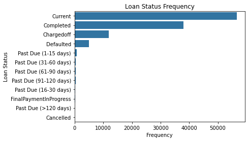

```python
# assigning the first color in the color palette to a color variable to use as an argument to prevent too much colors
color = sns.color_palette()[0]
# sorting by descending order using value_counts and then assigning the index to an order variable to use as the order argument
order = loan.LoanStatus.value_counts().index
# using the seaborn's countplot function to plot a bar chart to display the frequency of the different loan statuses
sns.countplot(data=loan, y='LoanStatus', color=color, order=order)

# creating a function for chart name, x and y labels, to avoid repetition in using the plt function
def labels(a,b,c):
    """
    This function gives chart title, x and y axis
    --------
    It aims to avoid repetition by taking in three parameters for the chart title and both the x and y axis labels
    """
    return plt.title(a),plt.ylabel(b),plt.xlabel(c)
labels('Loan Status Frequency','Loan Status','Frequency');
```

### Observation

From the visualization above, majority of the listings are still current loans, although a huge number of the loan listings have been completed. Only a handful are past behind on payment. Some have defaulted, while others have even been charged off due to perpetual defaulting. It can also be noted that people rarely cancel their loan listings as that category has the lowest frequency.

### Question

What different loan terms are there, what are their frequencies?

### Visualization

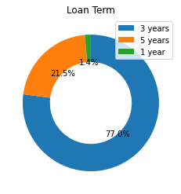

```python
pie_data = loan.Term.value_counts()
plt.pie(pie_data, autopct='%1.1f%%', startangle=90, counterclock=False, wedgeprops = {'width' : 0.4})
plt.title('Loan Term')
plt.legend(labels=['3 years','5 years','1 year']);
```

### Observation

Most of the loans taken were for 3 years(36 months), while 12 months loan had the least frequency. With some loans being for 5 years(60 months).

### Question

The `ProsperScore` column shows a custom risk score built using historical Prosper data. The score ranges from 1-10, with 10 being the best, or lowest risk score. Let's visualize the count and see what category different borrowers fall under.

### Visualization

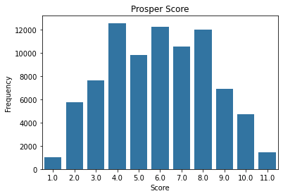

```python
color = sns.color_palette()[0]
sns.countplot(data=loan, x='ProsperScore', color=color)

labels('Prosper Score','Frequency','Score');
```

### Observation

The high points are 4, 6, and 8. The lowest being 1. This signifies that borrowers with the highest risk score are the least population in the dataset. Most borrowers fall within 4-8 risk score. There is also a category of borrowers that fall within 11. This could be as a result of incorrect data and the rows might need to be dropped.

### Question

The `ListingCategory` column is a very vital column as it tells us the reason the borrower took the loan. The category of the listing that the borrower selected when posting their listing: 0 - Not Available, 1 - Debt Consolidation, 2 - Home Improvement, 3 - Business, 4 - Personal Loan, 5 - Student Use, 6 - Auto, 7- Other, 8 - Baby&Adoption, 9 - Boat, 10 - Cosmetic Procedure, 11 - Engagement Ring, 12 - Green Loans, 13 - Household Expenses, 14 - Large Purchases, 15 - Medical/Dental, 16 - Motorcycle, 17 - RV, 18 - Taxes, 19 - Vacation, 20 - Wedding Loans. Let's try to find out the category that tops the list.

### Visualization

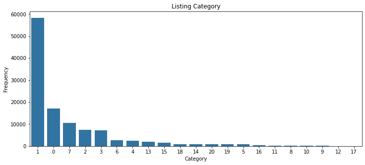

```python
# Let's create another function that we would use to call ethe figsize subsequently
def fig_size(a,b):
    # calling figsize parameters
    return plt.figure(figsize=(a,b))

fig_size(12,5)
color = sns.color_palette()[0]
order = loan['ListingCategory (numeric)'].value_counts().index
sns.countplot(data=loan, x='ListingCategory (numeric)', color=color, order=order)

labels('Listing Category','Frequency','Category');
```

### Observation

Debt Consolidation is the number one reason why people take out new loans. Home improvement loans and Business loans trail behind some loans termed 'Other' or 'Not available' to signify that the borrower didn't specify their reason. Green loans and loans for boats and RVs were the least types of listings created. People also took out loans to get engagement rings.

### Question

For the borrower state, we would try to see the states where the borrowers come from. Does location have a role to play in the reason people take out loans?. The `BorrowerState` column contains a two-letter abbreviation that denotes the state the borrower is from.

### Visualization

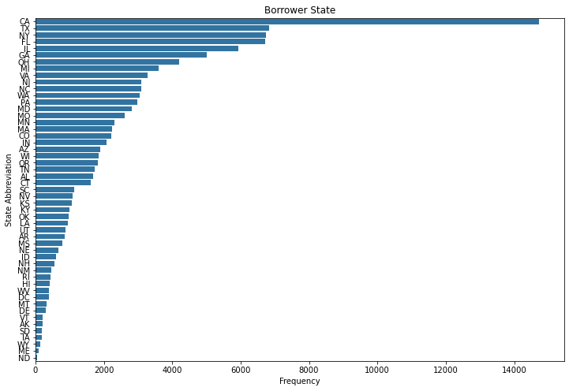

```python
fig_size(12,8);
color = sns.color_palette()[0]
order = loan.BorrowerState.value_counts().index
sns.countplot(data=loan, y='BorrowerState', color=color, order=order)

labels('Borrower State','State Abbreviation','Frequency');
```

### Observation

For this visualization, we had to make the plot bigger in order to fully see all the states contained in the population. California has the highest number of borrowes by a wide margin. Over two times the size of population of borrowers from any other state. Texas, New York, and Florida follow suit. North Dakota, Maine and Wyoming have the lowest count of borrowers.

### Question

As speculated earlier in the Features of Interest section, occupation should be a major deciding factor as to why people take loans. Let's see how true that is.

### Visualization

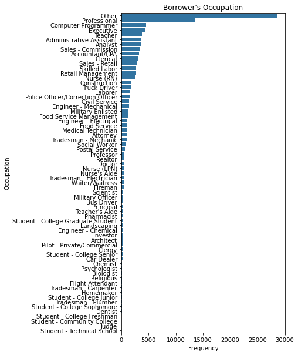

```python
fig_size(5,10)
color = sns.color_palette()[0]
order = loan.Occupation.value_counts().index
sns.countplot(data=loan, y='Occupation', color=color, order=order)

labels('Borrower\'s Occupation','Occupation','Frequency');
```

### Observation

A large number of borrowers specified their `Occupation` to be 'Others'. The most common occupations though are Professionals, Computer Programmers and Executives. At the bottom of the list we have Techincal School and College Freshman Students and weirdly Judges.

### Question

The `Employment Status` is quite similar to the `Occupation` column. What kind of employment do the people who take the most loans have?

### Visualization

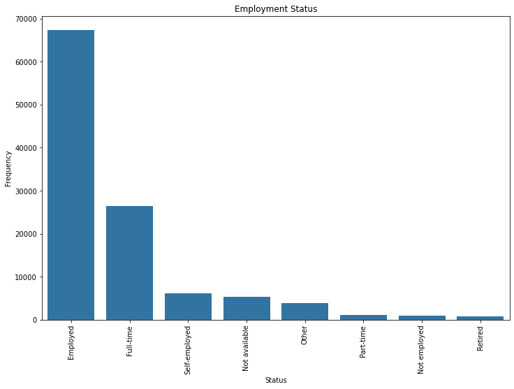

```python
fig_size(12,8)
color = sns.color_palette()[0]
order = loan.EmploymentStatus.value_counts().index
sns.countplot(data=loan, x='EmploymentStatus', color=color, order=order)

labels('Employment Status','Frequency','Status')
plt.xticks(rotation='90');
```

### Question

Does the fact that the borrower is a Home Owner make them want to take a loan?

### Visualization

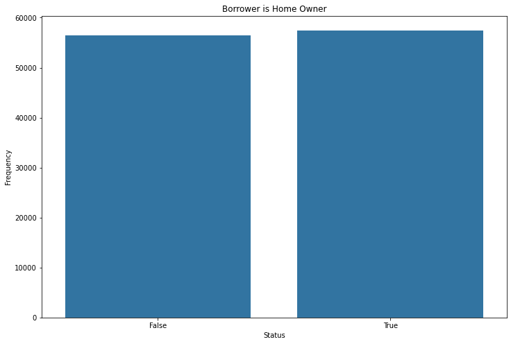

```python
fig_size(12,8)
color = sns.color_palette()[0]
order = loan.IsBorrowerHomeowner.value_counts().index
sns.countplot(data=loan, x='IsBorrowerHomeowner', color=color)

labels('Borrower is Home Owner','Frequency','Status');
```

### Observation

We couldm't get mugh information from the chart because the count of both categories are quite similar, a pie chart was also used to plot but it didn't make difference so a bar chart was the final choice as a slight difference in height can be seen compared to a pie chart.

### Question

People with what credit score range are most likely to take out loans?

### Visualization

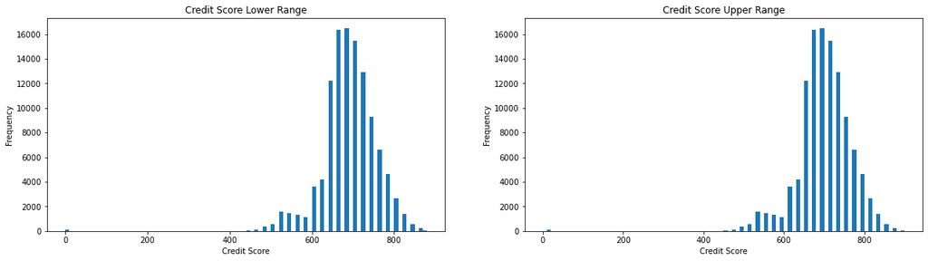

```python
plt.figure(figsize = [20, 5])

bins = np.arange(0, loan.CreditScoreRangeLower.max()+10, 10)
plt.subplot(1,2,1)
plt.hist(data=loan, x='CreditScoreRangeLower', bins=bins)
labels('Credit Score Lower Range','Frequency','Credit Score')

bins = np.arange(0, loan.CreditScoreRangeUpper.max()+10, 10)
plt.subplot(1,2,2)
plt.hist(data=loan, x='CreditScoreRangeUpper', bins=bins)
labels('Credit Score Upper Range','Frequency','Credit Score');
```

### Observation

Both the charts for the upper and lower ranges look alike. The range for most borrower falls between 650-750.

#### Question

What's the most common debt to income ratio?

#### Visualization

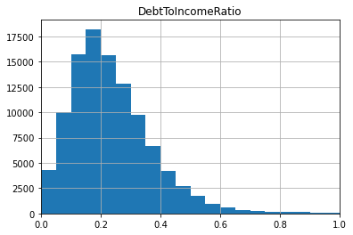

```python
fig_size(5,2)
loan.hist(column='DebtToIncomeRatio', bins=200)
plt.xlim(0,1);
```

### Observation

For this visualization, we had to limit the x range to see the data points more conspicously. The data is slightly skewed to the right.

### Question

Is there a particular income range associated with debt listing? Do people within a particular income range tend to take out more loans?

### Visualization

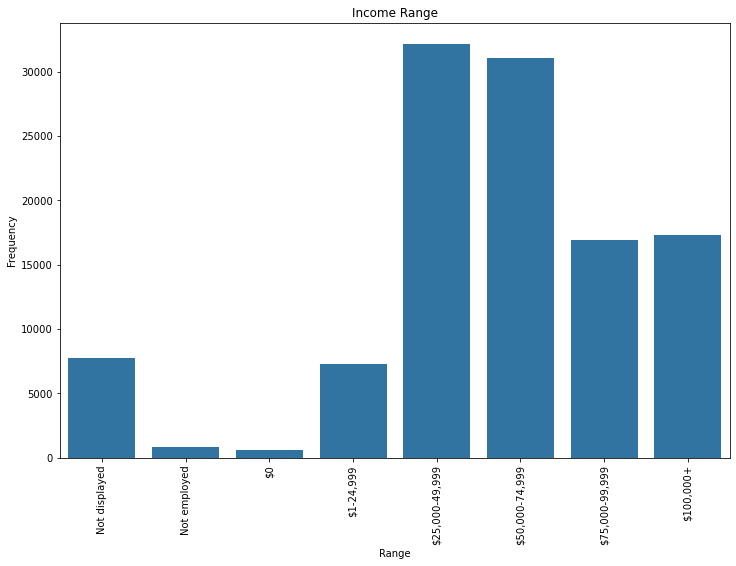

```python
fig_size(12,8)
color = sns.color_palette()[0]
order = ['Not displayed','Not employed','$0','$1-24,999','$25,000-49,999','$50,000-74,999','$75,000-99,999','$100,000+']
sns.countplot(data=loan, x='IncomeRange', color=color, order=order)

labels('Income Range','Frequency','Range')
plt.xticks(rotation='90');
```

### Observation

Income doesn't seem to play a role in why people take out loans as even people who earn over 100k still make up a huge part of the population. Unemployed people rarely take loans though, and this corroborates the previous chart on Employment Status.

### Question

Do people who are not able to verify their income also take loans?

### Visualization

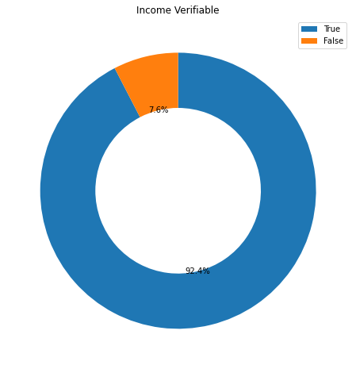

```python
fig_size(12,8)
pie_data = loan.IncomeVerifiable.value_counts()
plt.pie(pie_data, autopct='%1.1f%%', startangle=90, counterclock=False, wedgeprops = {'width' : 0.4})
plt.title('Income Verifiable')
plt.legend(labels=pie_data.index);
```

### Observation

Majority of the population were able to verify their incomes although 7.6% of people who couldn't verify still took loans.

### Question

The `TotalProsperLoan` column talks about the number of loan the borrower had before the new listing. Do borrowers take out more loans or are majority of the population fresh borrowers?

### Visualization

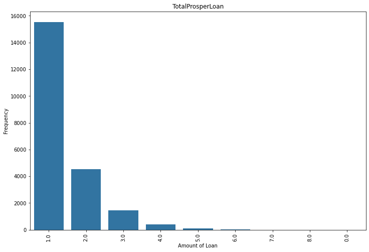

```python
fig_size(12,8)
color = sns.color_palette()[0]
order = loan.TotalProsperLoans.value_counts().index
sns.countplot(data=loan, x='TotalProsperLoans', color=color, order=order)

labels('TotalProsperLoan','Frequency','Amount of Loan')
plt.xticks(rotation='90');
```

### Question

How many investors are required to fund a loan. What's the majority range?

### Visualization

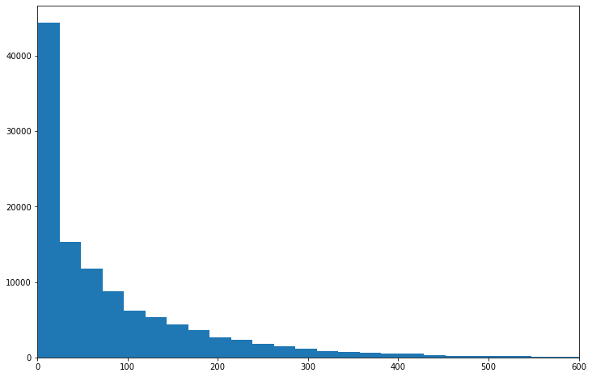

```python
fig_size(12,8)
plt.hist(data=loan, x='Investors', bins=50)
plt.xlim(0,600);
```

### Observation

Most loans are funded by very few investors, loans that have a lot of investor fundings are quite few.

## Bivariate Exploration

For the Bivariate Exploration, we would be comparing two variables and trying to see whether there is a correlation between them. Other types of visualizations would be used that allows for two variables to be compared, whether qualitative or quantitative.

### Question

Does the `IncomeRange` of the borrower after the `LoanOriginalAmount`, that is, the amount the borrower can get as a loan?

### Visualization

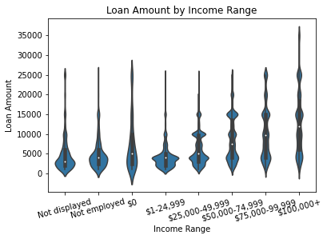

```python
color = sns.color_palette()[0]
order = ['Not displayed','Not employed','$0','$1-24,999','$25,000-49,999','$50,000-74,999','$75,000-99,999','$100,000+']
sns.violinplot(data=loan, x='IncomeRange', y='LoanOriginalAmount', color=color, order=order)
plt.xticks(rotation=15)
labels('Loan Amount by Income Range','Loan Amount','Income Range');
```

### Question

Does the `IncomeRange` determine if the borrower is a Home Owner or not.

### Visualization

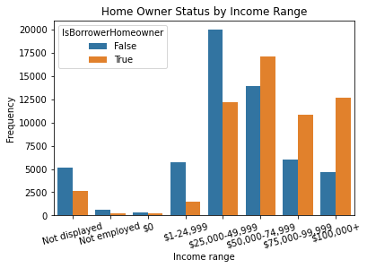

```python
order = ['Not displayed','Not employed','$0','$1-24,999','$25,000-49,999','$50,000-74,999','$75,000-99,999','$100,000+']
sns.countplot(data=loan, x='IncomeRange', hue='IsBorrowerHomeowner', order=order)
labels('Home Owner Status by Income Range','Frequency','Income range')
plt.xticks(rotation=15);
```

### Observation

It is obvious that the more the income range, the more likely it is for borrowers to be home owners. Borrowers that earn the most - 100k+ are over 100% more likely to be home owners than they're not. The trend continues downward through borrowers who earn 75k+ and 50k+ until it gets to 25k+ where borrowers who are not home owners are more than those who are, and it continues like that.

### Did you observe any interesting relationships between the other features (not the main feature(s) of interest)?

One interesting thing to note from the analysis of other variables would be the relationship between the income range and if the borrower is a home owner in the visualization above. People on the high income range spectrum were generally seen to own their own homes compared to the people in the low income range. Out of the population of the people who earned the most (100k+), the homeowners were over 2 times the number of those who didn't own a home. This was the opposite for people who earned the least(less than 25k), as the people who owned home in that populated were almost 3 times lesser than those who didn't.

## Multivariate Exploration

For this section of our exploration, we will be looking at the relationship between three or more variables and their correlation.

### Question

What's the distribution of people with verifiable income in the income range column?

### Visualization

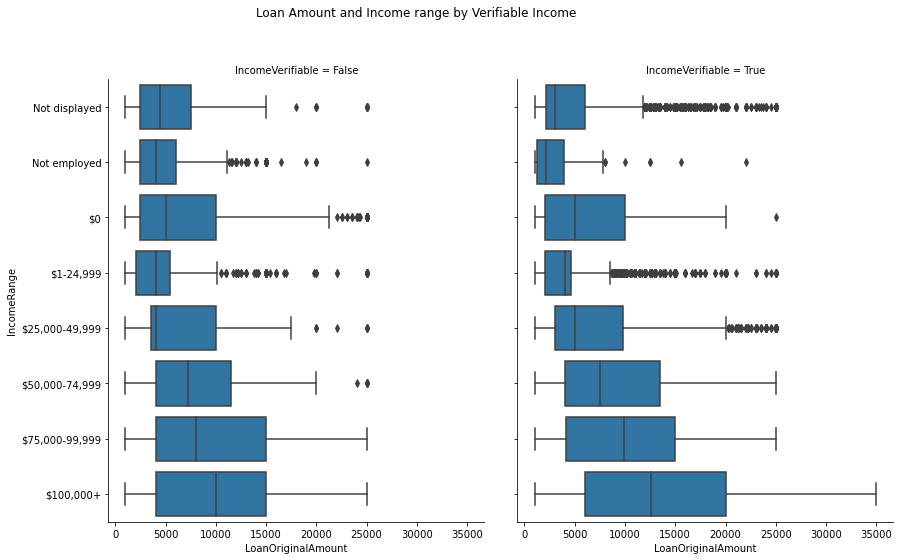

```python
order = ['Not displayed','Not employed','$0','$1-24,999','$25,000-49,999','$50,000-74,999','$75,000-99,999','$100,000+']
box = sns.FacetGrid(data = loan, col = 'IncomeVerifiable', height = 4)
box.map(sns.boxplot, 'LoanOriginalAmount', 'IncomeRange', order=order)
plt.suptitle('Loan Amount and Income range by Verifiable Income', y = 1.04)
box.fig.set_size_inches(14,8);
```

### Visualization

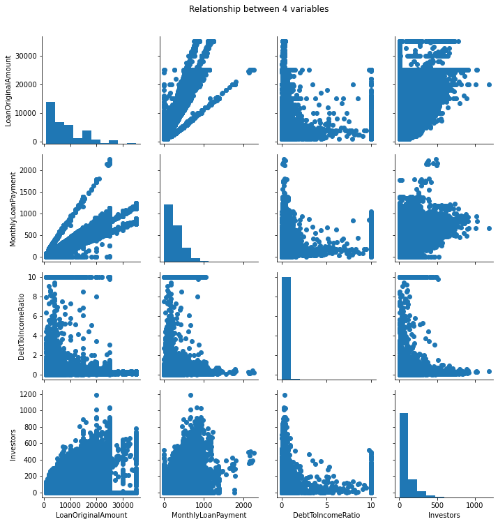

```python
mult = sns.PairGrid(data = loan, vars = ['LoanOriginalAmount', 'MonthlyLoanPayment', 'DebtToIncomeRatio','Investors'])
mult.map_diag(plt.hist)
mult.map_offdiag(plt.scatter)
plt.suptitle('Relationship between 4 variables', y = 1.04);
```

### Observation

A faceted scatterplot across 4 main variables only indicates how monthly payment and loan original amount are positively correlated, It also shows some sort of correlation between Investors and loan amount. The closest thing to a negative correlationn would be the relationship between Debt to Income Ratio and Investors, Monthly loan payment, and Loan Original Amount.